# Citeseq surface demultiplexing with aocseq

Noah Crooks and Mae Woods

## Citeseq and cell surface labelling

Data that has been multiplexed with Hash Tagged Oligos (HTOs - see https://www.10xgenomics.com/analysis-guides/demultiplexing-and-analyzing-5%E2%80%99-immune-profiling-libraries-pooled-with-hashtags.) and cell surface protein antibody oligos can be analyzed with aocseq.

These data are imported similarly to immuno-profiling data, but an additional step is added, such that cells are assigned to groups based on their hashtag counts, with probabilities generated by the GMM Demux algorithm (Xin et al. 2020). This example demonstrates how single cells can be labelled by their samples, receptors and or surface protein expression after demultiplexing.

## Install Required Packages

Aocseq is compatible with other cell analysis packages, including Seurat (Hao et al. 2023) and Single Cell Experiment (A et al. 2020). In contrast to other packages, the purpose of aocseq is to

**1.** provide a sample list of mixed cell types with accompanying datasheets and

**2.** Develop methods to score and rank cells based on optimal characteristics.

To accomplish this, genes of interest (GOIs) are defined prior to dimension reduction. These are genes that depend on the conditions of the experiment, are ubiquitously expressed and characterize cell types (of any frequency) e.g. clonotypes, receptor sequences and cell phenotypes. In this example, it will be demonstrated how GOIs can be used for metadata to subset cells after dimension reduction, even if a particular GOI is not included in the variable genes that define the **latent space**, highlighting aocseq’s purpose to display and analyze low frequency cellular subtypes.

To begin load the required packages.

```r
library(aocseq)
library(Seurat)
```

```r
library(ggplot2)
library(ggpubr)
library(circlize)
```

## Importing Data

Data import is handled by the CombineData function. For this vignette, the data used is from the paper “Chimeric Antigen Receptor-induced Antigen Loss Protects CD5.CART Cells From Fratricide Without Compromising On-target Cytotoxicity” (Ma et al. 2024). These data contain 13278 T cells that have been co-cultured with CD5.CART cells from 3 healthy donors. The scRNA sequencing in this study was used to understand the transcriptional and cell phenotypic changes that occur in healthy T cells as a result of co-culture with CAR T cells that are directed toward a surface protein that is expressed on the surface of a T cell. The data can be downloaded from zenodo. Before running CombineData, open terminal and make a file system AOCSEQ_Example, then download the example data and unzip the compressed files.

```bash
cd ~/Documents

mkdir AOCSEQ_Example

cd AOCSEQ_Example

mkdir Data, RDS, DataSheet, Figures

curl -O "https://zenodo.org/records/11286440/files/Figures-Rscripts.zip?download=1"

gunzip Figures-Rscripts.zip

cd Figures-Rscripts/Data

cp -r CD5 Data
```

The raw data consists of cell hashing and gene expression transcripts in 10X genomics feature barcode format. There are 6 input variables to CombineData. **gex.path** - the location of the feature barcode files, **marker.gene** - these are the GOIs, this example will show that CCL1 is expressed in donor 2 and 3 only and that, despite not being included as a variable feature, it can still be displayed with the dimension reduction. **save.dir** - this is the location to store a Seurat Object after demultiplexing. **my.demultiplex.index** - these are the surface values that you would like to run demultiplexing on, these hashtagged samples can be given names and in this example we call them **my.names.hashtags**. In this example, the first 7 slots in the antibody capture are surface protein and so we will not be demultiplexing these data. Finally, **my.n.ht.per.sample** is the number of hashtags used per sequencing run.

```r
gex.path=c("~/Documents/AOCSEQ_Example/SeqData/CD5")
marker.gene=c("IFNG","CD5","GZMB","CCR7","CCL1","CD28","CD27")
save.dir="~/Documents/AOCSEQ_Example/RDS/CD5.rds"
my.demultiplex.index = c(8, 9, 10)
my.names.hashtags = c('donor_1', 'donor_2','donor_3')
my.n.ht.per.sample = 3
```

Using these inputs, CombineData will create a list of Seurat objects, one for each sample/hashtag combination. CombineData can perform QC filtering based on the nFeature_RNA_lower, nFeature_RNA_upper, and percent.mt_upper parameters. These parameters represent the lower and upper cutoffs for RNA feature counts, and the upper bound for mitochondrial RNA percentage, respectively. If set, these parameters produce figures with lines that show the cutoff and cells that are excluded. To speed up the example, we have set nvariable_features=500 but this can take any value and the default is 3000.

```
#> 10X data contains more than one type and is being returned as a list containing matrices of each type.
#>   cluster        mu  variance       std size     alpha
#> 1       1 -1.480448 0.3251093 0.5701836 9789 0.6399294
#> 2       2  2.631537 0.3526647 0.5938558 5508 0.3600706
#>   cluster        mu  variance       std  size     alpha
#> 1       1  3.252396 0.5942977 0.7709071  2434 0.1591162
#> 2       2 -0.615226 0.2400263 0.4899248 12863 0.8408838
#>   cluster        mu variance       std size     alpha
#> 1       1 -1.778210 0.189220 0.4349943 6450 0.4216513
#> 2       2  1.296926 0.314026 0.5603802 8847 0.5783487
```

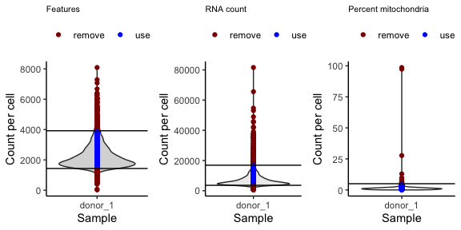

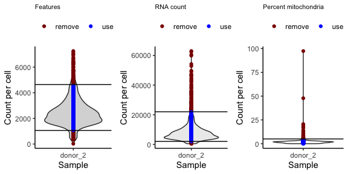

```
#> [1] "Starting scTRansform for sample 1..."
#> [1] "gene:  CCL1 is not present in SCT"
#> [1] "Continuing with remaining gois and replacing cutoff with count data..."
#> Warning in asMethod(object): sparse->dense coercion: allocating vector of size
#> 1.0 GiB
#> Warning in asMethod(object): sparse->dense coercion: allocating vector of size
#> 1.0 GiB
#> [1] "Starting scTRansform for sample 2..."
#> [1] "Sample: 2  not used for threshold"
#> [1] "Starting scTRansform for sample 3..."
#> [1] "Sample: 3  not used for threshold"
#> Warning in asMethod(object): sparse->dense coercion: allocating vector of size
#> 1.8 GiB
```

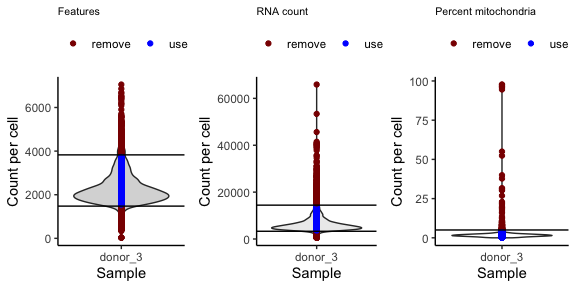

```r
CellData=CombineData(gex.path,
                     marker.gene,
                     file.saved=save.dir,
                     demultiplex=TRUE,
                     demultiplex.index=my.demultiplex.index,
                     nameshashtags=my.names.hashtags,
                     n.ht.per.sample = my.n.ht.per.sample,
                     nvariable_features=500,
                     QC_plots = TRUE)
```

Running CombineData will output the raw counts per sample and QC values. It will also provide a list of Seurat objects. In this case, we have three Seurat objects, one for each hashtag. As seen in the output from running the function CombineData, the GOI CCL1 was not included in Seurat’s sctransformed data and therefore it is not included in the variable features used for dimension reduction. Despite this, cells that express CCL1 can be subset in the data and displayed on a 2D UMAP embedding.

```r
my.ident.list=c("orig.ident")
my.save.dir="~/Documents/AOCSEQ_Example/Figures"
```

```r
UMAPReduce(
  CellData[[2]],
  save.dir=my.save.dir,
  ident.list=my.ident.list
)
```

```
#> Modularity Optimizer version 1.3.0 by Ludo Waltman and Nees Jan van Eck
#>
#> Number of nodes: 1545
#> Number of edges: 61880
#>
#> Running Louvain algorithm...
#> Maximum modularity in 10 random starts: 0.7969
#> Number of communities: 6
#> Elapsed time: 0 seconds
```

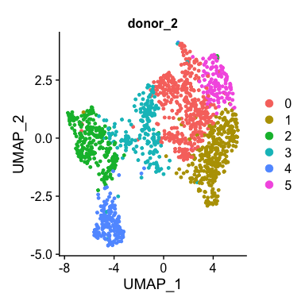

The next three plots split the UMAP by the different subsets of cells annotated by the GOIs CCl1, CD5 and GZMB

```r
my.ident.list=c("Threshold_CCL1","Threshold_CD5","Threshold_GZMB")
my.save.dir="~/Documents/AOCSEQ_Example/Figures"
```

```r
par(mfrow = c(2, 2))
UMAPReduce(
  CellData[[2]],
  save.dir=my.save.dir,
  ident.list=my.ident.list
)
```

```
#> Modularity Optimizer version 1.3.0 by Ludo Waltman and Nees Jan van Eck
#>
#> Number of nodes: 1545
#> Number of edges: 61880
#>
#> Running Louvain algorithm...
#> Maximum modularity in 10 random starts: 0.7969
#> Number of communities: 6
#> Elapsed time: 0 seconds
```

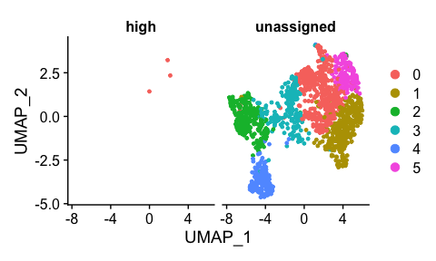

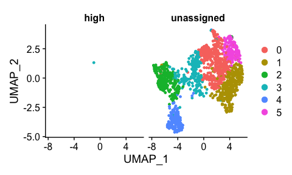

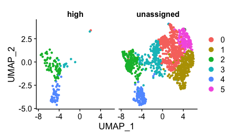

## Multimodal summary datasheets

In addition to using GMM demux for hashtag demultiplexing, aocseq can also be used to label cell phenotypes by their surface antibody expression. This example will use the function AnnotateCellTypes to produce a summary data sheet that can then be used to visualize the differences in frequency of the cell types across the three donors with the function SegmentPlot.

This time, GMM_demux can be called with the CellData that has been generated to split the cells into their CD4 and CD8 subsets, since the expression of surface CD5 and and CD62L was not bimodal, the cell types were further split by the upper quantile of surface antibody counts.

```r
for(k in 1:3){
  CellData[[k]] <- GMM_demux(my.names.hashtags[k],CellData[[k]], c(1,2),c("CD4","CD8"),set.col.name="MHC",Seurat_Object = TRUE)
  ncells=dim(CellData[[k]])[2]
  celltypes=c(as.character(1:8),"unassigned")
  CD5Counts=CellData[[k]]@assays$HTO@counts[3,]
  CD62LCounts=CellData[[k]]@assays$HTO@counts[7,]
  MHC=CellData[[k]]@meta.data$MHC
  CD5_high=unname(quantile(CD5Counts,.75))
  CD62L_high=unname(quantile(CD62LCounts,.75))
  cell_types=rep("unassigned",ncells)
  cell_types[unname(which(MHC=="CD4" & CD5Counts>CD5_high & CD62LCounts>CD62L_high))]=celltypes[1]
  cell_types[unname(which(MHC=="CD4" & CD5Counts>CD5_high & CD62LCounts<CD62L_high))]=celltypes[2]
  cell_types[unname(which(MHC=="CD4" & CD5Counts<CD5_high & CD62LCounts>CD62L_high))]=celltypes[3]
  cell_types[unname(which(MHC=="CD4" & CD5Counts<CD5_high & CD62LCounts>CD62L_high))]=celltypes[4]
  cell_types[unname(which(MHC=="CD8" & CD5Counts>CD5_high & CD62LCounts>CD62L_high))]=celltypes[5]
  cell_types[unname(which(MHC=="CD8" & CD5Counts>CD5_high & CD62LCounts<CD62L_high))]=celltypes[6]
  cell_types[unname(which(MHC=="CD8" & CD5Counts<CD5_high & CD62LCounts>CD62L_high))]=celltypes[7]
  cell_types[unname(which(MHC=="CD8" & CD5Counts<CD5_high & CD62LCounts<CD62L_high))]=celltypes[8]
  CellData[[k]]=AddMetaData(CellData[[k]],cell_types,col.name="cell_types")

  countcln=rep(0,ncells)
  countcln[unname(which(CellData[[k]]@meta.data$cell_types=="1"))]=length(unname(which(CellData[[k]]@meta.data$cell_types=="1")))
  countcln[unname(which(CellData[[k]]@meta.data$cell_types=="2"))]=length(unname(which(CellData[[k]]@meta.data$cell_types=="2")))
  countcln[unname(which(CellData[[k]]@meta.data$cell_types=="3"))]=length(unname(which(CellData[[k]]@meta.data$cell_types=="3")))
  countcln[unname(which(CellData[[k]]@meta.data$cell_types=="4"))]=length(unname(which(CellData[[k]]@meta.data$cell_types=="4")))
  countcln[unname(which(CellData[[k]]@meta.data$cell_types=="5"))]=length(unname(which(CellData[[k]]@meta.data$cell_types=="5")))
  countcln[unname(which(CellData[[k]]@meta.data$cell_types=="6"))]=length(unname(which(CellData[[k]]@meta.data$cell_types=="6")))
  countcln[unname(which(CellData[[k]]@meta.data$cell_types=="7"))]=length(unname(which(CellData[[k]]@meta.data$cell_types=="7")))
  countcln[unname(which(CellData[[k]]@meta.data$cell_types=="8"))]=length(unname(which(CellData[[k]]@meta.data$cell_types=="8")))
  CellData[[k]]=AddMetaData(CellData[[k]],countcln,col.name="countcln")

  Threshold_CD4=rep("unassigned",ncells)
  Threshold_CD4[unname(which(CellData[[k]]@meta.data$CD4cells=="1"))]="high"
  CellData[[k]]=AddMetaData(CellData[[k]],Threshold_CD4,col.name="Threshold_CD4")
  Threshold_CD8=rep("unassigned",ncells)
  Threshold_CD8[unname(which(CellData[[k]]@meta.data$CD8cells=="1"))]="high"
  CellData[[k]]=AddMetaData(CellData[[k]],Threshold_CD8,col.name="Threshold_CD8A")
}
```

```
#>   cluster         mu   variance       std size     alpha
#> 1       1 -0.7635656 0.07499433 0.2738509  592 0.1554622
#> 2       2  0.1405569 0.05636349 0.2374100 3216 0.8445378
#>   cluster         mu   variance       std size     alpha
#> 1       1  2.2366200 0.20434349 0.4520437  541 0.1420693
#> 2       2 -0.3703739 0.09759045 0.3123947 3267 0.8579307
#>   cluster         mu   variance       std size     alpha
#> 1       1  0.4693112 0.08642977 0.2939894  802 0.5190939
#> 2       2 -0.5065781 0.07464383 0.2732102  743 0.4809061
#>   cluster         mu  variance       std size     alpha
#> 1       1  1.2586921 0.2112576 0.4596277  672 0.4349515
#> 2       2 -0.9688901 0.1613815 0.4017231  873 0.5650485
#>   cluster         mu   variance       std size     alpha
#> 1       1 -1.0301664 0.10846304 0.3293373  768 0.1151597
#> 2       2  0.1340735 0.08216519 0.2866447 5901 0.8848403
#>   cluster        mu  variance       std size    alpha
#> 1       1  1.808431 0.2506693 0.5006688  782 0.117259
#> 2       2 -0.240223 0.1123221 0.3351449 5887 0.882741
```

The function CombineData is designed to work with a control and perturbation to assign GOIs with “high” and “unassigned” annotation. In this example, we would like to see if CD5 mRNA is still expressed during surface CD5 downregulation. So lets set the CD5 GOI values again using the upper quantile per donor sample.

```r
for(k in 1:3){
  ncells=dim(CellData[[k]])[2]
CD5p=match("CD5",row.names(CellData[[k]]@assays$RNA@counts))
CD5t=unname(quantile(CellData[[k]]@assays$RNA@counts[CD5p,],.75))
Threshold_CD5=rep("unassigned",ncells)
Threshold_CD5[unname(which(CellData[[k]]@assays$RNA@counts[CD5p,]>CD5t))]="high"
CellData[[k]]@meta.data$Threshold_CD5=Threshold_CD5
}
```

```r
CD4DataSheet=AnnotateCellTypes(CellData,goi="CD4",names.spreadsheet=c("donor1","donor2","donor3"),path="~/Documents/AOCSEQ_Example/DataSheet/",TCR = FALSE,cellType = "cell_types")
```

```
#> [1] "path="
#> [1] "~/Documents/AOCSEQ_Example/DataSheet/CD4/SummaryTable.csv"
#> [1] "Assigning counts for ranking..."
#> [1] "Assigning proportional specificity..."
```

```r
CD8DataSheet=AnnotateCellTypes(CellData,goi="CD8A",names.spreadsheet=c("donor1","donor2","donor3"),path="~/Documents/AOCSEQ_Example/DataSheet/",TCR = FALSE,cellType = "cell_types")
```

```
#> [1] "path="
#> [1] "~/Documents/AOCSEQ_Example/DataSheet/CD8A/SummaryTable.csv"
#> [1] "Assigning counts for ranking..."
#> [1] "Assigning proportional specificity..."
```

```r
CD5DataSheet=AnnotateCellTypes(CellData,goi="CD5",names.spreadsheet=c("donor1","donor2","donor3"),path="~/Documents/AOCSEQ_Example/DataSheet/",TCR = FALSE,cellType = "cell_types")
```

```
#> [1] "path="
#> [1] "~/Documents/AOCSEQ_Example/DataSheet/CD5/SummaryTable.csv"
#> [1] "Assigning counts for ranking..."
#> [1] "Assigning proportional specificity..."
```

The Summary data sheet for the CD4+ cell types is displayed below. Each cell type is listed in the first column and the percentage of cells that make up that cell type for the cells labelled by their mRNA expression of CD4 mRNA transcripts is listed for all three donors. In this table you can see that the percentage of cells with abundance CD4 mRNA transcripts is concordant with the high expression on the surface labeling.

```r
CD4DataSheet
```

```
#>   Clone cell_types donor1 CD4 (%) donor1 CD8 (%) donor1 (%) donor1 Cells
#> 1                2       19.74026              0   19.74026          385
#> 2                4       23.70370              0   23.70370          405
#> 3                8        0.00000              0    0.00000          254
#> 4                1       23.85621              0   23.85621          306
#> 5                7        0.00000              0    0.00000           80
#> 6                6        0.00000              0    0.00000           66
#> 7                5        0.00000              0    0.00000           28
#>   donor2 CD4 (%) donor2 CD8 (%) donor2 (%) donor2 Cells donor3 CD4 (%)
#> 1       41.77215              0   41.77215           79      52.610966
#> 2       21.50538              0   21.50538           93      33.507853
#> 3        0.00000              0    0.00000          356       3.275109
#> 4       23.52941              0   23.52941           68      41.034483
#> 5        0.00000              0    0.00000           97       0.000000
#> 6        0.00000              0    0.00000           59       0.000000
#> 7        0.00000              0    0.00000           27       0.000000
#>   donor3 CD8 (%) donor3 (%) donor3 Cells avg
#> 1              0  52.610966          766 410
#> 2              0  33.507853          573 357
#> 3              0   3.275109          458 356
#> 4              0  41.034483          290 222
#> 5              0   0.000000          130 103
#> 6              0   0.000000            6  44
#> 7              0   0.000000           13  23
```

The number of cells in each cell type is also included in the summary tables and the average number of cells per type is ordered by size and in the column avg. Now these tables can be used to plot the proportion of the cell types shared between the donors. Although there was insufficient capture of surface protein to conclude on the effect of CD5.CAR T cells on healthy resting T cells by comparative analysis between donors, the sharing of the high and low frequency phenotypes across all donors suggests the cells that survive co-culture have similar phenotypes.

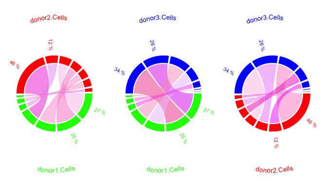

```r
par(mfrow = c(1, 3))

my.summarydf=read.csv("~/Documents/AOCSEQ_Example/DataSheet/CD5/SummaryTable.csv")
my.names=c("donor1.Cells","donor2.Cells")
my.segment.names=c("donor1.Cells","donor2.Cells")
n.segments=7
tune.gap=3
segmentPlot(my.summarydf,names=my.names,segment.names=my.segment.names,n.segments=7,tune.gap=3,segment.names.spacer="23mm",percentage.spacer.1="8mm",percentage.spacer.2="8mm",segment.col=c("green","red"))

my.summarydf=read.csv("~/Documents/AOCSEQ_Example/DataSheet/CD5/SummaryTable.csv")
my.names=c("donor1.Cells","donor3.Cells")
my.segment.names=c("donor1.Cells","donor3.Cells")
n.segments=7
tune.gap=3
segmentPlot(my.summarydf,names=my.names,segment.names=my.segment.names,n.segments=7,tune.gap=3,segment.names.spacer="23mm",percentage.spacer.1="8mm",percentage.spacer.2="8mm")

my.summarydf=read.csv("~/Documents/AOCSEQ_Example/DataSheet/CD5/SummaryTable.csv")
my.names=c("donor2.Cells","donor3.Cells")
my.segment.names=c("donor2.Cells","donor3.Cells")
n.segments=7
tune.gap=3
segmentPlot(my.summarydf,names=my.names,segment.names=my.segment.names,n.segments=7,tune.gap=3,segment.names.spacer="23mm",percentage.spacer.1="8mm",percentage.spacer.2="8mm",segment.col=c("red","blue"))
```

## References

A, R Lun, Becht E, Carey V, Carpp L, Geistlinger L, Rue-Albrecht K Marini F, Risso D, et al. 2020. “Orchestrating Single-Cell Analysis with Bioconductor.” *Nature Methods*. https://www.nature.com/articles/s41592-019-0654-x.

Hao, Yuhan, Tim Stuart, Madeline H Kowalski, Saket Choudhary, Paul Hoffman, Austin Hartman, Avi Srivastava, et al. 2023. “Dictionary Learning for Integrative, Multimodal and Scalable Single-Cell Analysis.” *Nature Biotechnology*. https://doi.org/10.1038/s41587-023-01767-y.

Ma, Royce, Mae Woods, Phillip Burkhardt, Noah Crooks, Dayenne G. van Leeuwen, Daniil Shmidt, Jacob Couturier, et al. 2024. “Chimeric Antigen Receptor-Induced Antigen Loss Protects Cd5.CART Cells from Fratricide Without Compromising on-Target Cytotoxicity.” Doi: 10.1016/j.xcrm.2024.101628. *Cell Reports Medicine* 5 (7). https://doi.org/10.1016/j.xcrm.2024.101628.

Xin, Hongyi, Qiuyu Lian, Yale Jiang, Jiadi Luo, Xinjun Wang, Carla Erb, Zhongli Xu, et al. 2020. “GMM-Demux: Sample Demultiplexing, Multiplet Detection, Experiment Planning, and Novel Cell-Type Verification in Single Cell Sequencing.” *Genome Biology* 21 (1): 188. https://doi.org/10.1186/s13059-020-02084-2.